# Petites envies de Noël

Après des mois de travail intense et des semaines de préparations pour l’arrivée de la petite Skimmia, il est temps de se pencher sur l’arrivée de Noël. Votre soutien sans failles pendant ces derniers mois est le plus beau cadeau de Noël que j’aurais pu espérer. J’ai cependant l’impression que cette réponse risque de ne pas plaire à tout le monde. J’ai compilé quelques petites idées de présents qui me feraient plaisir de recevoir pour Noël:

## Categorie: besoin de bouger après avoir mangé du chocolat pendant des mois

[figure not shown]

- [Chaussettes de vélo](https://www.decathlon.fr/p/chaussettes-velo-roadr-500-graph/_/R-p-330192?mc=8738992&c=ROSE) (45)
- Demonte pneu: [Decathlon](https://www.decathlon.fr/p/demonte-et-remonte-pneu-velo/_/R-p-300646?mc=8404829)
- Lacets serrage rapide triathlon: [exemple](https://www.alltricks.fr/C-143737-lacets)
- [Sac arrière vélo](https://www.alltricks.fr/F-41498-bagagerie/P-449817-sacoche_de_selle_zefal_z_adventure_r17_noir?_gl=1*a1y51r*_up*MQ..&gclid=EAIaIQobChMI_Oj8iNvW8wIVlZ3VCh3wiQSUEAQYAiABEgIBPvD_BwE)
- Support vélo plafond: [exemple](https://www.decathlon.fr/p/support-velo-pour-plafond/_/R-p-X8612111?mc=8612111)
- [combinaison de Triathlon](https://www.decathlon.fr/p/combinaison-trifonction-ld-triathlon-bleue-marine-homme/_/R-p-305604?mc=8530279&c=BLEU) (M)
- nouvelles chaussures de course: [marque Asics en 44/45](https://www.decathlon.fr/p/chaussures-de-running-homme-asics-gel-ziruss-4-bleue-orange/_/R-p-314656?mc=8619196)
- [Feux arrrière de vélo avec détection de voiture](https://www.decathlon.fr/p/radar-garmin-varia-rtl515/_/R-p-X8675596?mc=8675596)
- Pneu tubeless pour vélo de route: marque continental taille 700x25
- Chaussures vélo pour cales auto: [exemple](https://www.decathlon.fr/p/chaussures-de-velo-route-shimano-rc300-noir/_/R-p-X8627670?mc=8627670)

## Categorie: Skiiiimmmiiiiaaaa

- Friandises de dressage
- Kit de fixation pour vélo: [exemple](https://www.zooplus.fr/shop/chiens/sport_canin/laisse_chien_kit_separation_velo_sport_chien/15211)
- GPS pour ne jamais la perdre: [Kippy EVO](https://www.kippy.eu/fr/product/kippy-evo-brown-wood)

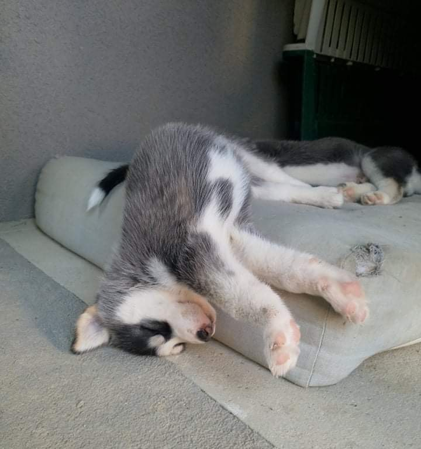

## Categorie: apparement il faut que je me cultive un peu

[figure not shown]

- Livre: “On the Origin of Species” de Charles Darwin (en anglais et occasion si possible ou [FNAC](https://livre.fnac.com/a2555563/Charles-Darwin-On-the-origin-of-species#int=:NonApplicable%7CNonApplicable%7CNonApplicable%7C2555563%7CNonApplicable%7CL1))
- PhD Comic book (1, 2, 3, 4, ou 5): disponible [ici](http://phdcomics.com/store/product.php?pid=1)
- Livre: “Grand Trail” de Frédéric Berg
- Tourne disque avec connection bluetooth: [exemple](https://www.fnac.com/mp43960670/Fenton-Rp165-Platine-Vinyle-Avec-2-Haut-parleurs-Integres-Bois-Technologie-Bluetooth-3-Vitesses-De-Disques-33-45-Et-78-Tours-Design-Simple-Et-elegant/w-4#omnsearchpos=4)

## Categorie: n’entre pas dans les autres categories

- Chocolat
- Tapis d’entrée avec Ortie, Skimmia et Ricin: [ici](https://kadonimo.com/products/tapis-personnalise-bienvenue-a-la-maison?fbclid=IwAR3xvvpJrTyFSzscgNfQRAJF7TwTYSs8eDha7VdaIJwXU4Kswx4zWHmCaOI) (Célia peut aider pour le design ;) )
- Terrarium ou kit pour le construire: [exemples](https://www.etsy.com/shop/LesBeauxtanistes?ref=simple-shop-header-name&listing_id=991239679)
- Mini-outils gravure ponçage : [exemple](https://www.mr-bricolage.fr/Surgeres/mini-outil-135w-210-accessoires-grup.html)
- Ponçeuse électrique
- Casque bluetooth réducteur de bruit: [Sony WH-1000XM3 Noir](https://www.fnac.com/Casque-Bluetooth-a-reduction-de-bruit-Sony-WH-1000XM3-Noir/a12774087/w-4)

[figure not shown]